# R Programming in Data Science: High Velocity Data

Mark Niemann-Ross

4/29/2018

MNR’s contact information [LinkedIn:](https://www.linkedin.com/in/markniemannross/) [Github:](https://github.com/mnr) [More Learning:](http://niemannross.com/link/mnratlil)

# Baseline Function

The R language tries to make programming as easy as possible, but at the cost of slower performance.

There is a long list of suggested strategies to realize substantial performance improvements.

Some of them are useful when working with high-velocity data and some are useful when working with high-volume data.

In this chapter, let’s implement some of the high-velocity strategies and see how they affect execution speed. To start, I’ve created a script that accesses the high velocity data we’ve been working with.

Let me show you the script and its performance.

```r
collectOneSecond <- function() {
  oneSecData <- data.frame(
    "V1" = NA,
    "V2" = NA,
    "V3" = NA,
    "V4" = NA
  )

  # amountOfRunTime <- now() + seconds(1)

  # while (amountOfRunTime > now()) {
  for (i in 1:100) {

    newData <- read.table(HighVelSimTxt)

    if (newData$V3 > 128) {
      newData$V4 <- "higher"
    } else {
      newData$V4 <- "lower"
    }

    oneSecData <- rbind(oneSecData, newData)
  }

  return(oneSecData)
}
```

# if else

Sometimes you need to test in a loop.

In our starting script, the code adds a column with a calculated value. It does this by testing the value of one column and placing the result in the new column. This is done with a standard if…then…else test There are faster alternatives. Let’s look at how to optimize this.

```r
ifElse_collectOneSecond <- function() {
  oneSecData <- data.frame("V1" = NA,
                           "V2" = NA,
                           "V3" = NA,
                           "V4" = NA)

  # amountOfRunTime <- now() + seconds(1)

  # while (amountOfRunTime > now()) {
  for (i in 1:100) {

    newData <- read.table(HighVelSimTxt)

    newData$V4 <- ifelse(newData$V3 > 128, "higher", "lower")

    oneSecData <- rbind(oneSecData, newData)
  }

  # it would be better to place this outside of the loop
  # newData$V4 <- ifelse(newData$V3 > 128,
  #                      "higher",
  #                      "lower")

  return(oneSecData)
}
```

# Avoid copying data

Earlier, we looked at the cost of appending data to an object. Let’s spend a brief moment looking at the efficiency of a pre-allocated data structure vs the efficiency of appending data.

```r
nocopy_collectOneSecond <- function() {
  oneSecData <- vector(mode = "list", 10000)
  dataIDX <- 1

  # amountOfRunTime <- now() + seconds(1)

  # while (amountOfRunTime > now()) {
  for (i in 1:100) {

    newData <- read.table(HighVelSimTxt)

    if (newData$V3 > 128 ) {
      newData$V4 <- "higher"
    } else {
      newData$V4 <- "lower"
    }

    # oneSecData <- rbind(oneSecData, newData)
    oneSecData[[dataIDX]] <- newData
    dataIDX <- dataIDX + 1

  }

  # remove empty elements of oneSecondOfData
  allGoodData <- oneSecData[!sapply(oneSecData, is.null)]

  return(allGoodData)
}
```

# All optimizations

Finally, let’s wrap all of these optimizations together to see if we’ve made any cumulative difference.

Let’s take a look at how this all fits together so that the data flows through the process again. Let’s run the starting script as a reminder Now let’s run the optimized version Some optimizations make a big difference – some don’t. Looking back over what we’ve learned, it’s important to remember to profile the code to find out what is worth optimizing and what isn’t worth our time.

```r
allOpt_collectOneSecond <- function() {
  oneSecData <- vector(mode = "list", 10000)
  dataIDX <- 1
  # amountOfRunTime <- now() + seconds(1)

  # while (amountOfRunTime > now()) {
  for (i in 1:100) {


    newData <- read.table(HighVelSimTxt)

    oneSecData[[dataIDX]] <- newData
    dataIDX <- dataIDX + 1
  }

  # remove empty elements of oneSecondOfData
  allGoodData <- oneSecData[!sapply(oneSecData, is.null)]

  # vectorize the creation of V4
  allGoodData <- lapply(allGoodData,
                        function(x) { return(c(x$V1,
                                               x$V2,
                                               x$V3,
                                               ifelse(x$V3 > 128, "higher", "lower")))})

  return(allGoodData)

}
```

# Run the benchmark

In the last video, we saw that our assumptions about code efficiency might not have been what we first assumed.

Microbenchmark is a package that provides a great way to quantify this. Let’s spend a brief amount of time exploring this function.

```r
benchmarkresults <- microbenchmark(
  original = collectOneSecond(),
  ifElse = ifElse_collectOneSecond(),
  nocopy = nocopy_collectOneSecond(),
  allOptimizations = allOpt_collectOneSecond()
)
```

```r
print(benchmarkresults)
```

```
## Unit: milliseconds
##              expr       min       lq     mean   median       uq      max
##          original 155.57556 224.4259 260.3843 255.9085 280.5973 576.6912
##            ifElse 136.05178 225.5334 265.0957 249.9633 282.5952 534.9796
##            nocopy 105.33224 148.1906 186.2995 174.6233 204.7295 525.6529
##  allOptimizations  96.46009 167.0394 198.5924 187.1805 206.2939 579.5924
##  neval
##    100
##    100
##    100
##    100
```

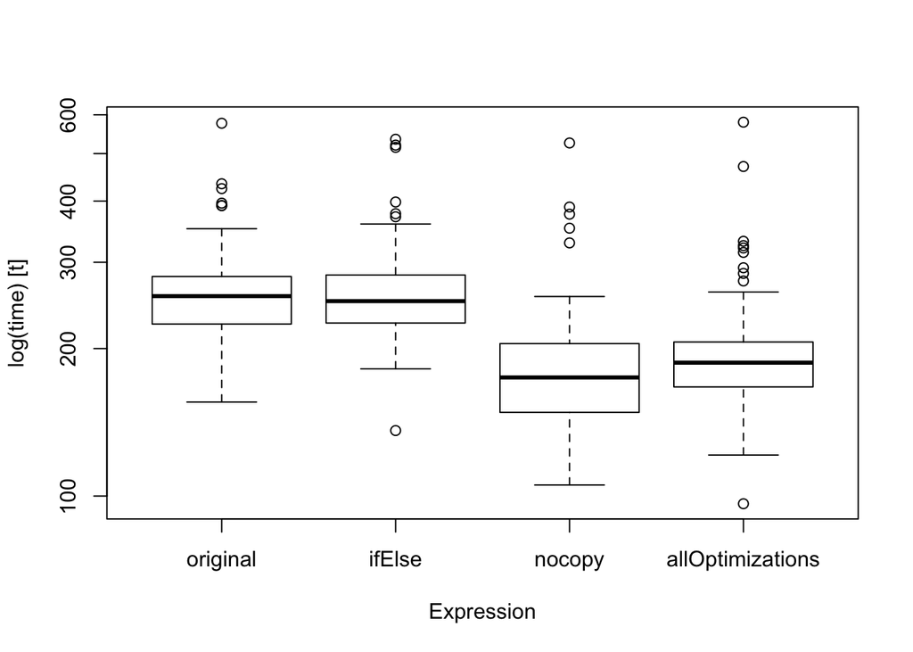

```r
boxplot(benchmarkresults)
```

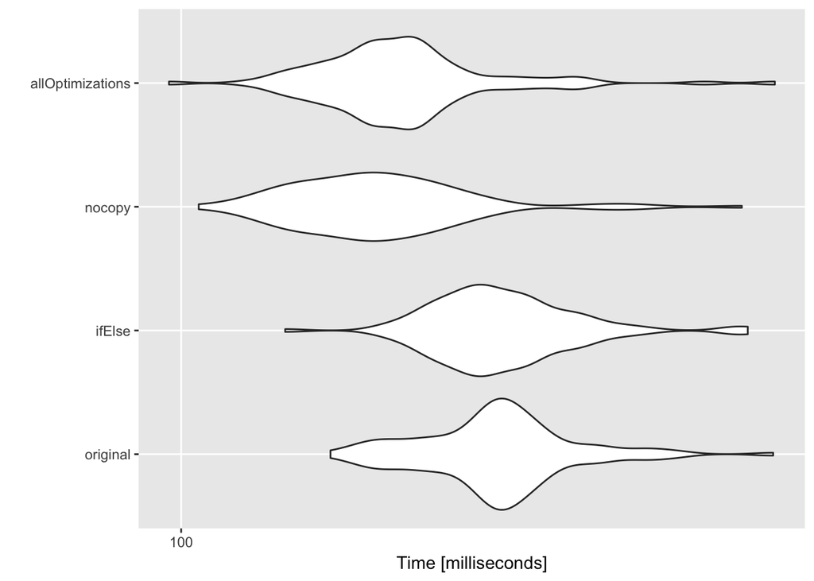

```r
autoplot(benchmarkresults)
```